# transfer

```python
import os
import cv2
import pandas as pd
import numpy as np
import re
import matplotlib.pyplot as plt
import seaborn as sns
from sklearn.model_selection import train_test_split

import torch
from torch.utils.data import Dataset, DataLoader

from tqdm.notebook import tqdm
from sklearn.linear_model import LogisticRegression
from sklearn.metrics import accuracy_score, classification_report
from sklearn.preprocessing import LabelEncoder, StandardScaler
```

```python
dataset_path = "/kaggle/input/lip-reading-3/VIDEO_CROPPED+NUOVI"
data_list = []

for root, dirs, files in os.walk(dataset_path):
    for file_name in files:
        if file_name.lower().endswith('.mp4'):

            user = os.path.basename(root)

            name_without_ext = os.path.splitext(file_name)[0]
            word = name_without_ext.split('_')[-1].upper()
            word = re.sub(r'^\d+', '', word)

            video_path = os.path.join(root, file_name)
            cap = cv2.VideoCapture(video_path)

            frame_count = int(cap.get(cv2.CAP_PROP_FRAME_COUNT))
            fps = cap.get(cv2.CAP_PROP_FPS)
            width = int(cap.get(cv2.CAP_PROP_FRAME_WIDTH))
            height = int(cap.get(cv2.CAP_PROP_FRAME_HEIGHT))
            cap.release()

            data_list.append({
                'user': user,
                'file': file_name,
                'word': word,
                'frames': frame_count,
                'res': f"{width}x{height}",
                'fps': fps
            })

df = pd.DataFrame(data_list)

print(f"Video founded: {len(df)}")
print(df.head())
```

```
Video founded: 1439
       user                           file   word  frames      res    fps
0  StefanoM    VID_20240426_172412_BED.mp4    BED      42  256x128  29.95
1  StefanoM  VID_20240426_172539_MOUSE.mp4  MOUSE      48  256x128  29.95
2  StefanoM  VID_20240426_172319_PIZZA.mp4  PIZZA      53  256x128  29.95
3  StefanoM    VID_20240426_172420_BED.mp4    BED      39  256x128  29.95
4  StefanoM  VID_20240426_172431_MONEY.mp4  MONEY      57  256x128  29.95
```

```python
corrections = {
    'CHIAR': 'CHAIR',
    'SMARPHONE': 'SMARTPHONE',
    'COFFEE':'COFFE',
    'WHITCH':'WITCH',
    'WHICH':'WITCH',
    'CLOCK2':'CLOCK',
    'BOWL':'BALL',
    'PLAIN':'PLACE'
}
df['word'] = df['word'].replace(corrections)
```

```python
counts = df['word'].value_counts()
low_frequency_words = counts[counts < 10]
print(low_frequency_words)
print(low_frequency_words.count())
```

```
word
FIGHT           9
CAT             9
SMARTPHONE      9
FLAG            9
SOFT            9
PENCILCASE      9
CHILDREN        9
THANKS          9
BOTTLE          9
FLUID           8
DAY             8
DESKTOP         8
GLASS           8
CUP             7
PENCIL          7
NAME            7
OCEAN           7
WINDOW          7
LESSON          7
INTELLIGENCE    6
PILLOW          6
HAT             6
MOON            5
ROBOTICS        5
Name: count, dtype: int64
24
```

```python
df = df.groupby('word').filter(lambda x: len(x) >= 10)
print(f"Total number of Video: {len(df)}")
```

```
Total number of Video: 1256
```

```python
specific_users = ['SERGIO', 'GIUSEPPE']

mask_val_test = df['user'].str.upper().isin(specific_users)

df_train = df[~mask_val_test].copy()
df_val_test = df[mask_val_test].copy()

df_val, df_test = train_test_split(df_val_test, test_size=0.5, random_state=42, shuffle=True)

print(f"-----------------------")
print(f'Total video filmed by SERGIO and GIUSEPPE = {mask_val_test.sum()}')
print(f"Training Set:   {len(df_train)} video")
print(f"Validation Set: {len(df_val)} video")
print(f"Test Set:       {len(df_test)} video")
print(f"-----------------------")

assert len(set(df_train.index).intersection(set(df_val.index))) == 0
assert len(set(df_val.index).intersection(set(df_test.index))) == 0
```

```
-----------------------
Total video filmed by SERGIO and GIUSEPPE = 258
Training Set:   998 video
Validation Set: 129 video
Test Set:       129 video
-----------------------
```

```python
# parole da rimuovere (< 5 nel Training)
train_counts = df_train['word'].value_counts()
words_to_remove = train_counts[train_counts < 5].index.tolist()

len_train_old = len(df_train)
len_val_old = len(df_val)
len_test_old = len(df_test)

df_train = df_train[~df_train['word'].isin(words_to_remove)].copy()
df_val = df_val[~df_val['word'].isin(words_to_remove)].copy()
df_test = df_test[~df_test['word'].isin(words_to_remove)].copy()

print("-" * 40)
print(f"Training Set:   rimossi {len_train_old - len(df_train)} video. (Nuovo totale: {len(df_train)})")
print(f"Validation Set: rimossi {len_val_old - len(df_val)} video. (Nuovo totale: {len(df_val)})")
print(f"Test Set:       rimossi {len_test_old - len(df_test)} video. (Nuovo totale: {len(df_test)})")
print("-" * 40)
```

```
----------------------------------------
Training Set:   rimossi 12 video. (Nuovo totale: 986)
Validation Set: rimossi 19 video. (Nuovo totale: 110)
Test Set:       rimossi 29 video. (Nuovo totale: 100)
----------------------------------------
```

```python
import numpy as np
import cv2
import os
from tqdm.notebook import tqdm

MAX_FRAMES = 90
TARGET_SIZE = (64, 32)

def load_data_with_masking(df, base_path):
    X_data = []      # Tensore video (N, 90, 32, 64, 3)
    y_data = []      # Etichette
    masks = []       # Maschere booleane (N, 90)

    kept = 0
    skipped = 0

    for row in tqdm(df.itertuples(), total=len(df)):
        full_path = os.path.join(base_path, row.user, row.file)

        cap = cv2.VideoCapture(full_path)
        frames = []
        while True:
            ret, frame = cap.read()
            if not ret: break
            frame = cv2.resize(frame, TARGET_SIZE)
            frames.append(frame)
        cap.release()

        L = len(frames)

        if L > MAX_FRAMES:
            skipped += 1
            continue

        if L == 0:
            skipped += 1
            continue

        padded_video = np.zeros((MAX_FRAMES, TARGET_SIZE[1], TARGET_SIZE[0], 3), dtype=np.uint8)

        mask = np.zeros((MAX_FRAMES,), dtype=np.float32)
        padded_video[:L] = np.array(frames)

        mask[:L] = 1.0

        X_data.append(padded_video)
        masks.append(mask)
        y_data.append(row.word)
        kept += 1

    print(f"\n✅ Completato!")
    print(f"📹 Video mantenuti: {kept}")
    print(f"🗑️ Video scartati (> {MAX_FRAMES} frames o errori): {skipped}")

    return np.array(X_data), np.array(y_data), np.array(masks)

print("--- Caricamento Training Set ---")
X_train, y_train_raw, mask_train = load_data_with_masking(df_train, dataset_path)

print("\n--- Caricamento Test Set ---")
X_test, y_test_raw, mask_test = load_data_with_masking(df_test, dataset_path)

# Normalizzazione pixel (0-255 -> 0-1)
print("\n🛁 Normalizzazione pixel...")
X_train = X_train.astype('float32') / 255.0
X_test = X_test.astype('float32') / 255.0

from sklearn.preprocessing import LabelEncoder
from keras.utils import to_categorical

le = LabelEncoder()
y_train_enc = le.fit_transform(y_train_raw)
# Gestione label sicura
y_test_enc = []
valid_idx = []
for i, w in enumerate(y_test_raw):
    if w in le.classes_:
        y_test_enc.append(le.transform([w])[0])
        valid_idx.append(i)

X_test = X_test[valid_idx]
mask_test = mask_test[valid_idx]
y_test_enc = np.array(y_test_enc)

num_classes = len(le.classes_)
y_train_cat = to_categorical(y_train_enc, num_classes)
y_test_cat = to_categorical(y_test_enc, num_classes)

print(f"\n📦 Shape finali:")
print(f"X_train: {X_train.shape} (Video)")
print(f"Mask_train: {mask_train.shape} (Maschere)")
print(f"y_train: {y_train_cat.shape} (Label)")
```

```
--- Caricamento Training Set ---
🔄 Elaborazione 986 video con Padding & Masking...
```

```
✅ Completato!
📹 Video mantenuti: 939
🗑️ Video scartati (> 90 frames o errori): 47

--- Caricamento Test Set ---
🔄 Elaborazione 100 video con Padding & Masking...
```

```
✅ Completato!
📹 Video mantenuti: 96
🗑️ Video scartati (> 90 frames o errori): 4

🛁 Normalizzazione pixel...
```

[output not shown]

```
📦 Shape finali:
X_train: (939, 90, 32, 64, 3) (Video)
Mask_train: (939, 90) (Maschere)
y_train: (939, 71) (Label)
```

## 6. Experiment 4: Transfer Learning with MobileNetV2 + LSTM

### 6.1. Motivation: Addressing Data Scarcity

The results from the previous experiments (Baseline, 2D CNN, and CNN-LSTM trained from scratch) consistently showed a low generalization capability (~2% accuracy on the Test Set). This strongly suggests that the dataset size (~13 samples per class) is insufficient for a Deep Convolutional Network to learn robust, subject-independent visual features from scratch. Instead of learning to detect generic lip edges and shapes, the networks were likely overfitting to the specific somatic traits of the training subjects.

To overcome this **"Small Data"** problem, we adopt a **Transfer Learning** strategy. Transfer Learning allows us to leverage the visual knowledge acquired by a state-of-the-art network trained on a massive dataset (ImageNet, 14 million images). Even though ImageNet does not contain specific lip-reading data, the low-level features learned by the network (edge detection, curves, texture analysis) are universal and can be repurposed as a powerful feature extractor for our task.

### 6.2. Proposed Architecture

We selected **MobileNetV2** as the backbone feature extractor due to its efficiency and lightweight architecture, which is particularly suitable for processing video sequences (high volume of frames) without saturating GPU memory.

The new pipeline is defined as follows:

1. **Feature Extraction (Frozen Backbone):**
   - We instantiate a **MobileNetV2** pre-trained on ImageNet, removing the top classification layers (`include_top=False`).
   - **Freezing:** The weights of MobileNetV2 are **frozen** (`trainable=False`). This ensures that the pre-learned filters are preserved and forces the model to use them as-is, drastically reducing the number of trainable parameters and the risk of overfitting.
   - **TimeDistributed Application:** The frozen model is applied independently to each of the 90 frames in the sequence.
2. **Spatial Aggregation:** We apply `GlobalAveragePooling2D` to the feature maps output by MobileNetV2. This converts the spatial information into a compact feature vector for each frame.
3. **Temporal Modeling (LSTM):** The sequence of 90 feature vectors is passed to a **Bidirectional LSTM**, which is now responsible solely for learning the temporal dynamics of the words, relying on the robust visual features provided by MobileNet.

This approach theoretically separates the visual problem (solved by MobileNet) from the temporal problem (solved by LSTM), simplifying the learning task for our specific dataset.

```
🧹 Sessione resettata per il Transfer Learning.
INFO:tensorflow:Using MirroredStrategy with devices ('/job:localhost/replica:0/task:0/device:GPU:0', '/job:localhost/replica:0/task:0/device:GPU:1')
```

```
I0000 00:00:1769524492.791621      55 gpu_device.cc:2019] Created device /job:localhost/replica:0/task:0/device:GPU:0 with 13942 MB memory:  -> device: 0, name: Tesla T4, pci bus id: 0000:00:04.0, compute capability: 7.5
I0000 00:00:1769524492.795475      55 gpu_device.cc:2019] Created device /job:localhost/replica:0/task:0/device:GPU:1 with 13942 MB memory:  -> device: 1, name: Tesla T4, pci bus id: 0000:00:05.0, compute capability: 7.5
```

```
🏗️ Costruzione Modello Transfer Learning (MobileNetV2 + LSTM)...
Downloading data from https://storage.googleapis.com/tensorflow/keras-applications/mobilenet_v2/mobilenet_v2_weights_tf_dim_ordering_tf_kernels_1.0_224_no_top.h5
9406464/9406464 ━━━━━━━━━━━━━━━━━━━━ 0s 0us/step
```

```
Model: "functional"
```

```
┏━━━━━━━━━━━━━━━━━━━━━┳━━━━━━━━━━━━━━━━━━━┳━━━━━━━━━━━━┳━━━━━━━━━━━━━━━━━━━┓
┃ Layer (type)        ┃ Output Shape      ┃    Param # ┃ Connected to      ┃
┡━━━━━━━━━━━━━━━━━━━━━╇━━━━━━━━━━━━━━━━━━━╇━━━━━━━━━━━━╇━━━━━━━━━━━━━━━━━━━┩
│ video_input         │ (None, 90, 32,    │          0 │ -                 │
│ (InputLayer)        │ 64, 3)            │            │                   │
├─────────────────────┼───────────────────┼────────────┼───────────────────┤
│ time_distributed    │ (None, 90, 1, 2,  │  2,257,984 │ video_input[0][0] │
│ (TimeDistributed)   │ 1280)             │            │                   │
├─────────────────────┼───────────────────┼────────────┼───────────────────┤
│ mask_input          │ (None, 90)        │          0 │ -                 │
│ (InputLayer)        │                   │            │                   │
├─────────────────────┼───────────────────┼────────────┼───────────────────┤
│ time_distributed_1  │ (None, 90, 1280)  │          0 │ time_distributed… │
│ (TimeDistributed)   │                   │            │                   │
├─────────────────────┼───────────────────┼────────────┼───────────────────┤
│ reshape (Reshape)   │ (None, 90, 1)     │          0 │ mask_input[0][0]  │
├─────────────────────┼───────────────────┼────────────┼───────────────────┤
│ multiply (Multiply) │ (None, 90, 1280)  │          0 │ time_distributed… │
│                     │                   │            │ reshape[0][0]     │
├─────────────────────┼───────────────────┼────────────┼───────────────────┤
│ not_equal           │ (None, 90, 1280)  │          0 │ multiply[0][0]    │
│ (NotEqual)          │                   │            │                   │
├─────────────────────┼───────────────────┼────────────┼───────────────────┤
│ masking (Masking)   │ (None, 90, 1280)  │          0 │ multiply[0][0]    │
├─────────────────────┼───────────────────┼────────────┼───────────────────┤
│ any (Any)           │ (None, 90)        │          0 │ not_equal[0][0]   │
├─────────────────────┼───────────────────┼────────────┼───────────────────┤
│ bidirectional       │ (None, 256)       │  1,442,816 │ masking[0][0],    │
│ (Bidirectional)     │                   │            │ any[0][0]         │
├─────────────────────┼───────────────────┼────────────┼───────────────────┤
│ dense (Dense)       │ (None, 128)       │     32,896 │ bidirectional[0]… │
├─────────────────────┼───────────────────┼────────────┼───────────────────┤
│ dropout (Dropout)   │ (None, 128)       │          0 │ dense[0][0]       │
├─────────────────────┼───────────────────┼────────────┼───────────────────┤
│ dense_1 (Dense)     │ (None, 71)        │      9,159 │ dropout[0][0]     │
└─────────────────────┴───────────────────┴────────────┴───────────────────┘
```

```
 Total params: 3,742,855 (14.28 MB)
```

```
 Trainable params: 1,484,871 (5.66 MB)
```

```
 Non-trainable params: 2,257,984 (8.61 MB)
```

[output not shown]

```
I0000 00:00:1769524927.505994   15978 cuda_dnn.cc:529] Loaded cuDNN version 91002
I0000 00:00:1769524927.506006   15979 cuda_dnn.cc:529] Loaded cuDNN version 91002
```

```
118/118 ━━━━━━━━━━━━━━━━━━━━ 0s 355ms/step - accuracy: 0.0355 - loss: 4.2489INFO:tensorflow:Reduce to /job:localhost/replica:0/task:0/device:CPU:0 then broadcast to ('/job:localhost/replica:0/task:0/device:CPU:0',).
118/118 ━━━━━━━━━━━━━━━━━━━━ 670s 3s/step - accuracy: 0.0356 - loss: 4.2484 - val_accuracy: 0.0000e+00 - val_loss: 4.5157 - learning_rate: 5.0000e-04
118/118 ━━━━━━━━━━━━━━━━━━━━ 47s 393ms/step - accuracy: 0.0882 - loss: 3.8358 - val_accuracy: 0.0000e+00 - val_loss: 4.5092 - learning_rate: 5.0000e-04
118/118 ━━━━━━━━━━━━━━━━━━━━ 46s 390ms/step - accuracy: 0.1549 - loss: 3.4846 - val_accuracy: 0.0000e+00 - val_loss: 4.7482 - learning_rate: 5.0000e-04
118/118 ━━━━━━━━━━━━━━━━━━━━ 46s 390ms/step - accuracy: 0.2021 - loss: 3.2669 - val_accuracy: 0.0000e+00 - val_loss: 4.8013 - learning_rate: 5.0000e-04
118/118 ━━━━━━━━━━━━━━━━━━━━ 0s 350ms/step - accuracy: 0.2099 - loss: 3.0589
Epoch 5: ReduceLROnPlateau reducing learning rate to 0.0002500000118743628.
118/118 ━━━━━━━━━━━━━━━━━━━━ 46s 391ms/step - accuracy: 0.2099 - loss: 3.0589 - val_accuracy: 0.0000e+00 - val_loss: 4.8202 - learning_rate: 5.0000e-04
118/118 ━━━━━━━━━━━━━━━━━━━━ 46s 389ms/step - accuracy: 0.2821 - loss: 2.7025 - val_accuracy: 0.0000e+00 - val_loss: 5.0348 - learning_rate: 2.5000e-04
118/118 ━━━━━━━━━━━━━━━━━━━━ 46s 391ms/step - accuracy: 0.3016 - loss: 2.5809 - val_accuracy: 0.0000e+00 - val_loss: 5.2782 - learning_rate: 2.5000e-04
118/118 ━━━━━━━━━━━━━━━━━━━━ 0s 352ms/step - accuracy: 0.3717 - loss: 2.4320
Epoch 8: ReduceLROnPlateau reducing learning rate to 0.0001250000059371814.
118/118 ━━━━━━━━━━━━━━━━━━━━ 46s 391ms/step - accuracy: 0.3716 - loss: 2.4321 - val_accuracy: 0.0000e+00 - val_loss: 5.2423 - learning_rate: 2.5000e-04
118/118 ━━━━━━━━━━━━━━━━━━━━ 47s 394ms/step - accuracy: 0.3957 - loss: 2.3066 - val_accuracy: 0.0000e+00 - val_loss: 5.3269 - learning_rate: 1.2500e-04
118/118 ━━━━━━━━━━━━━━━━━━━━ 47s 393ms/step - accuracy: 0.3948 - loss: 2.2468 - val_accuracy: 0.0000e+00 - val_loss: 5.4445 - learning_rate: 1.2500e-04
118/118 ━━━━━━━━━━━━━━━━━━━━ 0s 353ms/step - accuracy: 0.4009 - loss: 2.1439
Epoch 11: ReduceLROnPlateau reducing learning rate to 6.25000029685907e-05.
118/118 ━━━━━━━━━━━━━━━━━━━━ 46s 393ms/step - accuracy: 0.4009 - loss: 2.1439 - val_accuracy: 0.0000e+00 - val_loss: 5.3272 - learning_rate: 1.2500e-04
118/118 ━━━━━━━━━━━━━━━━━━━━ 47s 394ms/step - accuracy: 0.3781 - loss: 2.1457 - val_accuracy: 0.0000e+00 - val_loss: 5.4560 - learning_rate: 6.2500e-05
Epoch 12: early stopping
Restoring model weights from the end of the best epoch: 2.

⏱️ Tempo totale di training: 20.68 minuti
3/3 ━━━━━━━━━━━━━━━━━━━━ 248s 440ms/step - accuracy: 0.0000e+00 - loss: 4.4775

🏆 TEST ACCURACY (Transfer Learning): 0.00%
```

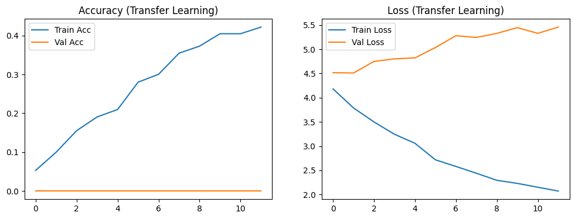

```python
import tensorflow as tf
from tensorflow.keras import layers, models, Input
from tensorflow.keras.callbacks import EarlyStopping, ReduceLROnPlateau
import matplotlib.pyplot as plt
import time

tf.keras.backend.clear_session()

INPUT_SHAPE = (90, 32, 64, 3)
NUM_CLASSES = 71
BATCH_SIZE = 8

def build_transfer_model():
    # INPUT
    video_input = Input(shape=INPUT_SHAPE, name='video_input')
    mask_input = Input(shape=(90,), name='mask_input')

    base_cnn = tf.keras.applications.MobileNetV2(
        weights='imagenet',
        include_top=False,
        input_shape=(32, 64, 3)
    )

    base_cnn.trainable = False

    x = layers.TimeDistributed(base_cnn)(video_input)

    x = layers.TimeDistributed(layers.GlobalAveragePooling2D())(x)


    mask_reshaped = layers.Reshape((90, 1))(mask_input)
    x = layers.Multiply()([x, mask_reshaped])

    x = layers.Masking(mask_value=0.0)(x)
    x = layers.Bidirectional(layers.LSTM(128, return_sequences=False, dropout=0.3))(x)

    x = layers.Dense(128, activation='relu')(x)
    x = layers.Dropout(0.4)(x)
    output = layers.Dense(NUM_CLASSES, activation='softmax')(x)

    model = models.Model(inputs=[video_input, mask_input], outputs=output)
    return model

strategy = tf.distribute.MirroredStrategy()

with strategy.scope():
    model = build_transfer_model()
    model.compile(optimizer=tf.keras.optimizers.Adam(learning_rate=0.0005),
                  loss='categorical_crossentropy',
                  metrics=['accuracy'])

model.summary()

start_time = time.time()

early_stop = EarlyStopping(monitor='val_loss', patience=10, restore_best_weights=True, verbose=1)
reduce_lr = ReduceLROnPlateau(monitor='val_loss', factor=0.5, patience=3, verbose=1)

history = model.fit(
    x=[X_train, mask_train],
    y=y_train_cat,
    validation_data=([X_test, mask_test], y_test_cat),
    epochs=40,
    batch_size=BATCH_SIZE,
    callbacks=[early_stop, reduce_lr],
    verbose=1
)

training_time = time.time() - start_time
print(f"\n⏱️ Tempo totale di training: {training_time/60:.2f} minuti")

loss, acc = model.evaluate([X_test, mask_test], y_test_cat)
print(f"\n🏆 TEST ACCURACY (Transfer Learning): {acc*100:.2f}%")

# Grafici
plt.figure(figsize=(12, 4))
plt.subplot(1, 2, 1)
plt.plot(history.history['accuracy'], label='Train Acc')
plt.plot(history.history['val_accuracy'], label='Val Acc')
plt.title('Accuracy (Transfer Learning)')
plt.legend()
plt.subplot(1, 2, 2)
plt.plot(history.history['loss'], label='Train Loss')
plt.plot(history.history['val_loss'], label='Val Loss')
plt.title('Loss (Transfer Learning)')
plt.legend()
plt.show()
```

### 6.3. Results and Discussion (Domain Gap Analysis)

- **Training Performance:** The model achieved a **Training Accuracy of approximately 40%**, with consistently decreasing loss. This demonstrates that the hybrid architecture has sufficient capacity to learn the mapping between video sequences and words. The network successfully learned to "read" the lips of the subjects present in the training set.
- **Validation Performance:** Despite effective learning on the training set, the **Validation Accuracy on unseen subjects remained at 0.00%**.

**Scientific Interpretation:** This extreme discrepancy (Subject Overfitting) confirms that the **"Subject Gap"** is the primary bottleneck. The somatic variations (mouth shape, presence of facial hair, lighting, articulation style) between the training group and the test group (Sergio, Giuseppe) are too significant for the model to generalize given that it only has ~13 examples per word. In summary: the model learned to recognize *who* is speaking, rather than recognizing *what* is being said.